## Multiple regression

We now extend linear regression so that our models can contain more variables.

A natural first approach is to assume additive effects, basically extending our line to a plane, or generalized version of a plane as we add more variables.

Multiple/multivariable regression represents one of the most widely used and successful methods in statistics.

One use of multivariable regression is for **adjustment**, that is trying to look at the relationship of a predictor and a response, while having, at some level, accounted for other variables (which can distort, or confound, the relationship between two others).

Another use is for **prediction**. To get a good prediction model you may need to incoporate lots of regressors. - How do we pick which predictors to include? - Problem of overfitting

### The linear model

- The general linear model extends simple linear regression by adding terms linearly into the model. \[ Y_i = \beta_1 X_{1i} + \beta_2 X_{2i} + \ldots + \beta_{p} X_{pi} + \epsilon_{i} = \sum_{k=1}^p X_{ik} \beta_j + \epsilon_{i} \]
- Here \(X_{1i}=1\) typically, so that an intercept is included.
- Least squares (and hence ML estimates under iid Gaussianity of the errors) minimizes \[ \sum_{i=1}^n \left(Y_i - \sum_{k=1}^p X_{ki} \beta_j\right)^2 \]
- Note, the important linearity is linearity in the coefficients. Thus \[ Y_i = \beta_1 X_{1i}^2 + \beta_2 X_{2i}^2 + \ldots + \beta_{p} X_{pi}^2 + \epsilon_{i} \] is still a linear model. (We've just squared the elements of the predictor variables.)

LS estimates

The least squares estimate for a coefficient of a multivariate regression model is exactly the regression (through the origin) estimate having removed the linear relationships with the other regressors from both the regressor and outcome.

In this sense, multivariate regression "adjusts" a coefficient for the linear impact of the other variables.

Think of it as follows. If we want an adjusted relationship between \(y\) and \(x\), keep taking residuals over confounders and do regression through the origin.

Interpretation of the coeficient

\[E[Y | X_1 = x_1, \ldots, X_p = x_p] = \sum_{k=1}^p x_{k} \beta_k\] So that \[ E[Y | X_1 = x_1 + 1, \ldots, X_p = x_p] - E[Y | X_1 = x_1, \ldots, X_p = x_p]\] \[= (x_1 + 1) \beta_1 + \sum_{k=2}^p x_{k}+ \sum_{k=1}^p x_{k} \beta_k = \beta_1 \] So that the interpretation of a multivariate regression coefficient is the expected change in the response per unit change in the regressor, holding all of the other regressors fixed.

Fitted values, residuals and residual variation

All of our SLR quantities can be extended to linear models

- Model \(Y_i = \sum_{k=1}^p X_{ik} \beta_{k} + \epsilon_{i}\) where \(\epsilon_i \sim N(0, \sigma^2)\)
- Fitted responses \(\hat Y_i = \sum_{k=1}^p X_{ik} \hat \beta_{k}\)
- Residuals \(e_i = Y_i - \hat Y_i\)
- Variance estimate \(\hat \sigma^2 = \frac{1}{n-p} \sum_{i=1}^n e_i ^2\), the \(n-p\) so that \(E(\hat \sigma^2)=\sigma^2\).
- Get predicted responses at new values, \(x_1, \ldots, x_p\), plugging them into the model \(\sum_{k=1}^p x_{k} \hat \beta_{k}\)
- Coefficients have standard errors, \(\hat \sigma_{\hat \beta_k}\), and \((\hat \beta_k - \beta_k)/\hat \sigma_{\hat \beta_k} \sim t_{n-p}\).
- Predicted responses have standard errors and we can calculate predicted and expected response intervals.

Linear models

- Linear models are the most important applied statistical and machine learning techniqe, *by far*.
- Some amazing things that you can accomplish with linear models
  - Flexibly fit complicated functions.
  - Fit factor variables as predictors.
  - Uncover complex multivariate relationships with the response.
  - Build accurate prediction models.

### Model checking (residuals again)

We can generalize this idea to the vertical distances between the observed data and the fitted surface in multivariable settings.

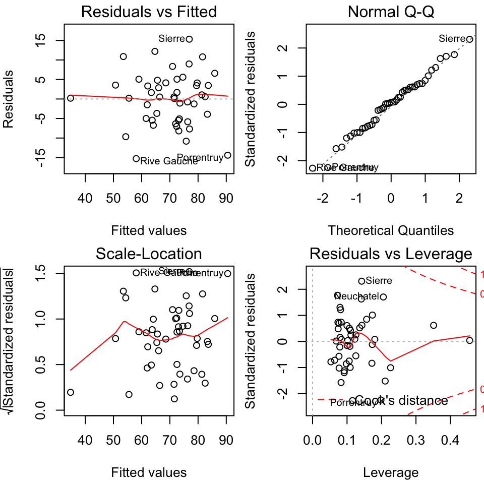

```r
data(swiss)
fit <- lm(Fertility ~ . , data = swiss); plot(fit)
```

Outlying, high leverage and influential and points

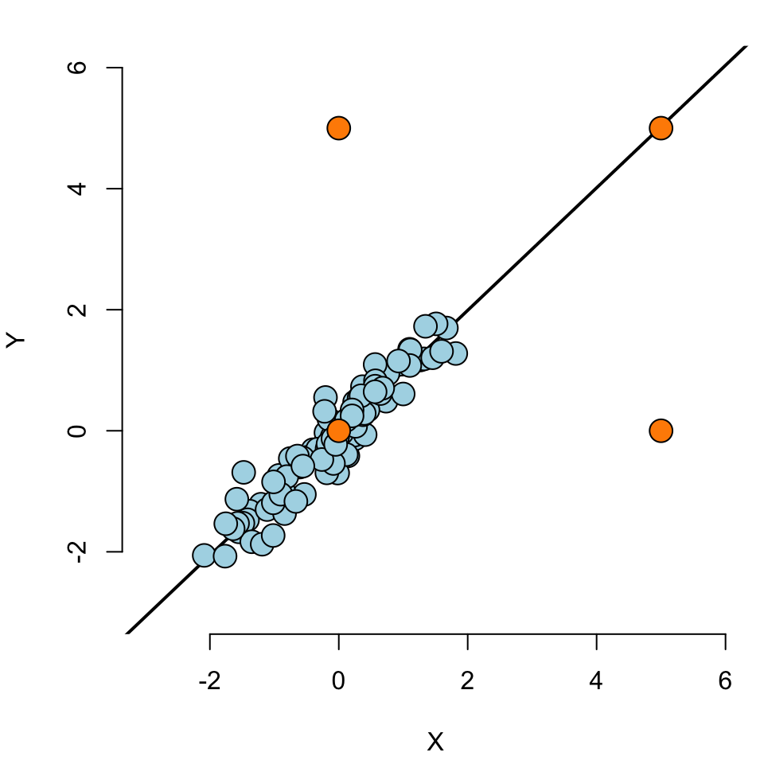

Outliers

- can be the result of spurious or real processes.
- can conform to the regression relationship (i.e being marginally outlying in X or Y, but not outlying given the regression relationship).
- can have varying degrees of influence.

Do `?influence.measures` to see the full suite of influence measures in stats.

Be wary of simplistic rules for diagnostic plots and measures. The use of these tools is context specific.

- Patterns in your residual plots generally indicate some poor aspect of model fit. These can include:
  - Heteroskedasticity.
  - Missing model terms.
  - Temporal patterns.
- Residual QQ plots investigate normality of the errors.
- Leverage measures can be useful for diagnosing data entry errors.
- Influence measures: 'how does deleting or including this point impact a particular aspect of the model'.

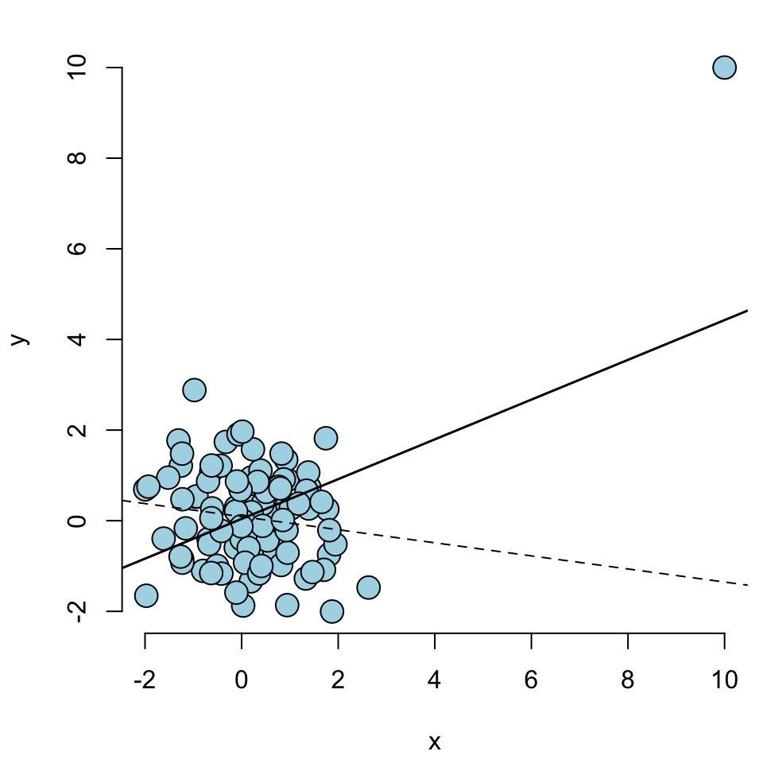

The point `c(10, 10)` (the 1st one in the order) has created a strong regression relationship where there shouldn't be one.

```r
round(hatvalues(fit)[1 : 10], 3); round(dfbetas(fit)[1 : 10, 2], 3)
```

```
#>     1     2     3     4     5     6     7     8     9    10
#> 0.509 0.012 0.023 0.012 0.010 0.010 0.022 0.018 0.010 0.016
#>      1      2      3      4      5      6      7      8      9     10
#>  8.198  0.017 -0.218  0.034  0.000  0.000 -0.144 -0.065  0.010  0.050
```

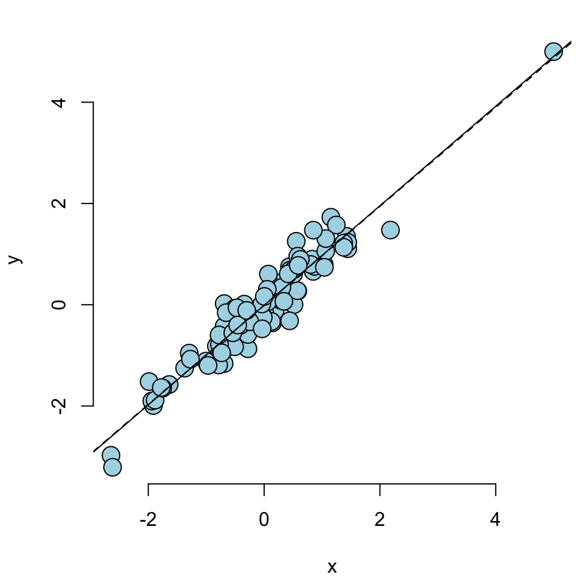

Looking at some of the diagnostics

```r
round(hatvalues(fit2)[1 : 10], 3); round(dfbetas(fit2)[1 : 10, 2], 3)
```

```
#>     1     2     3     4     5     6     7     8     9    10
#> 0.240 0.013 0.012 0.033 0.010 0.017 0.012 0.024 0.012 0.012
#>      1      2      3      4      5      6      7      8      9     10
#>  0.199 -0.059  0.002 -0.025  0.001 -0.047  0.004 -0.133  0.051 -0.050
```

### Model selection

> How do we chose what variables to include in a regression model?

No single easy answer exists and the most reasonable answer would be "It depends.".

- Now our focus is modeling:
  - In modeling our interest lies in parsimonious, interpretable representations of the data that enhance our understanding of the phenomena under study.
  - In prediction, we're less concerned with interpretability, what we want is to come up with the best prediction with respect to a specific loss function (then, models with lots of variables, automated search algorithms).
- Parsimony: finding the simplest model to explain what we're looking at, so as simple as possible, but no simpler.
- What happens if we omit a variable that we should have included? What about including variables that are unimportant?
- A model is a lense through which to look at our data, to teach us something true about your data set.
- George Box: *all models are wrong, some models are useful*.
- Good modeling decisions are context dependent: a good model for prediction versus one for studying mechanisms versus one for trying to establish causal effects may not be the same.

General rules

- Omitting important variables (**underfitting**) results in bias in the coeficients of interest - unless their regressors are uncorrelated with the omitted ones.
  - Randomization can help. But,If there's too many unobserved confounding variables, even randomization won't help you.
- Including unnecessary variables (**overfitting**) increases (actual) standard errors of other regressors - unless these are uncorrelated with the included ones.
- \(R^2\) increases monotonically as more regressors are included.

Variance inflation 1 (you can skip this and the next simulation)

```r
n <- 100; nosim <- 1000
x1 <- rnorm(n); x2 <- rnorm(n); x3 <- rnorm(n);
betas <- sapply(1 : nosim, function(i){
  y <- x1 + rnorm(n, sd = .3)
  c(coef(lm(y ~ x1))[2],
    coef(lm(y ~ x1 + x2))[2],
    coef(lm(y ~ x1 + x2 + x3))[2])
})
dim(betas)
```

```
#> [1]    3 1000
```

```r
round(apply(betas, 1, sd), 5)
```

```
#>      x1      x1      x1
#> 0.02651 0.02656 0.02666
```

Variance inflation 2

```r
n <- 100; nosim <- 1000
x1 <- rnorm(n); x2 <- x1/sqrt(2) + rnorm(n) /sqrt(2)
x3 <- x1 * 0.95 + rnorm(n) * sqrt(1 - 0.95^2);
betas <- sapply(1 : nosim, function(i){
  y <- x1 + rnorm(n, sd = .3)
  c(coef(lm(y ~ x1))[2],
    coef(lm(y ~ x1 + x2))[2],
    coef(lm(y ~ x1 + x2 + x3))[2])
})
round(apply(betas, 1, sd), 5)
```

```
#>      x1      x1      x1
#> 0.03297 0.04461 0.11274
```

Variance inflation factors

- We don't know \(\sigma\), so we can't actually calculate the exact variance inflation
- However, \(\sigma\) drops out of the relative standard errors.
- The **variance inflation factor** (VIF) is the increase in the variance for the ith regressor compared to the ideal setting where it is orthogonal to the other regressors.
  - (The square root of the VIF is the increase in the sd …)
- Remember, variance inflation is only part of the picture. We want to include certain variables, even if they dramatically inflate our variance.

Revisting our previous simulation (you can skip)

```r
##doesn't depend on which y you use
y <- x1 + rnorm(n, sd = .3)
a <- summary(lm(y ~ x1))$cov.unscaled[2,2]
c(summary(lm(y ~ x1 + x2))$cov.unscaled[2,2],
  summary(lm(y~ x1 + x2 + x3))$cov.unscaled[2,2]) / a
```

```
#> [1]  1.820585 10.985296
```

```r
temp <- apply(betas, 1, var); temp[2 : 3] / temp[1]
```

```
#>        x1        x1
#>  1.830739 11.694624
```

Swiss data (you can skip, use simply the R function `vif`)

```r
data(swiss)
fit1 <- lm(Fertility ~ Agriculture, data = swiss)
a <- summary(fit1)$cov.unscaled[2,2]
fit2 <- update(fit, Fertility ~ Agriculture + Examination, data=swiss)
fit3 <- update(fit, Fertility ~ Agriculture + Examination + Education, data=swiss)
  c(summary(fit2)$cov.unscaled[2,2],
    summary(fit3)$cov.unscaled[2,2]) / a
```

```
#> [1] 1.891576 2.089159
```

Swiss data VIFs,

```r
library(car)
fit <- lm(Fertility ~ . , data = swiss)
vif(fit)
```

```
#>      Agriculture      Examination        Education         Catholic
#>         2.284129         3.675420         2.774943         1.937160
#> Infant.Mortality
#>         1.107542
```

```r
sqrt(vif(fit))
```

```
#>      Agriculture      Examination        Education         Catholic
#>         1.511334         1.917138         1.665816         1.391819
#> Infant.Mortality
#>         1.052398
```

What about residual variance estimation?

- If we underfit the model, the variance estimate is biased.
- If we correctly or overfit the model, including all necessary covariates and/or unnecessary covariates, the variance estimate is unbiased, however, the variance of the variance is larger if we include unnecessary variables.

Covariate selection

- If the models of interest are nested and without lots of parameters differentiating them, it's fairly uncontroversial to use **nested likelihood ratio tests**. (Example to follow.)
- **Automated covariate selection** can be a choice if the covariate space one wants to explore is quite rich.
- For the purposes of prediction, there are many modern methods for traversing large model spaces.
- **Principal components** or factor analytic models on covariates are often useful for reducing complex covariate spaces.
- Good design can often eliminate the need for complex model searches at analyses; though often control over the design is limited.

How to do nested model testing in R

```r
fit1 <- lm(Fertility ~ Agriculture, data = swiss)
fit3 <- update(fit, Fertility ~ Agriculture + Examination + Education)
fit5 <- update(fit, Fertility ~ Agriculture + Examination + Education + Catholic + Infant.Mortality)
anova(fit1, fit3, fit5)
```

```
#> Analysis of Variance Table
#>
#> Model 1: Fertility ~ Agriculture
#> Model 2: Fertility ~ Agriculture + Examination + Education
#> Model 3: Fertility ~ Agriculture + Examination + Education + Catholic +
#>     Infant.Mortality
#>   Res.Df    RSS Df Sum of Sq      F    Pr(>F)
#> 1     45 6283.1
#> 2     43 3180.9  2    3102.2 30.211 8.638e-09 ***
#> 3     41 2105.0  2    1075.9 10.477 0.0002111 ***
#> ---
#> Signif. codes:  0 '***' 0.001 '**' 0.01 '*' 0.05 '.' 0.1 ' ' 1
```